# Nucleotide Diversity

James Diao

June 20, 2016

$Nucleotide\ Diversity\ (\pi) = \sum_{ij} x_i x_j \pi_{ij}$

## QUESTIONS

1. Can we see people who have the simple reference sequence? Or does this data only include sequences with variants?
2. Should I be trying to normalize Allele_Frequency to sum to 1?
3. Am I able to generalize my nucleotide diversity statistic from the ExAC dataset to the general population?
4. Am I allowed to take the range of chromosome positions as the total number of nucleotides?
5. Can I assume that only 1 variant occurs per sequence?

### Calculate number of nucleotides in each gene

```r
nts.mybpc3 <- max(input.mybpc3$Position)-min(input.mybpc3$Position)+1
nts.myh7 <- max(input.myh7$Position)-min(input.myh7$Position)+1
```

```
## MYBPC3 gene length (nt)   MYH7 gene length (nt)
##                   28900                   20973
```

Assumption: nts = range in chromosomal positions of variants. I took this number because it’s actually larger than the transcription region range given by UCSC GB.

### Extract data for MYBPC3 and MYH7

#### *data.mybpc3 is a list, containing a data frame for each ethnicity, with Position, Count, Number, and Freq

Note: I took all variants at each chromosomal position and summed their counts, including insertions and deletions.

```r
str(data.mybpc3)
```

```
## List of 7
##  $ Afr    :'data.frame': 310 obs. of  4 variables:
##   ..$ Position: chr [1:310] "47348266" "47348284" "47350194" "47350197" ...
##   ..$ Count   : num [1:310] 36 1 1 1 2 ...
##   ..$ Number  : num [1:310] 10392 10400 10280 10294 10294 ...
##   ..$ Freq    : num [1:310] 3.46e-03 9.62e-05 9.73e-05 9.71e-05 1.94e-04 ...
##  $ E.Asian:'data.frame': 241 obs. of  4 variables:
##   ..$ Position: chr [1:241] "47348266" "47350286" "47350287" "47350569" ...
##   ..$ Count   : num [1:241] 1 9 5502 1 1 ...
##   ..$ Number  : num [1:241] 8652 8580 8502 8654 8654 ...
##   ..$ Freq    : num [1:241] 0.000116 0.001049 0.647142 0.000116 0.000116 ...
##  $ NFE    :'data.frame': 792 obs. of  4 variables:
##   ..$ Position: chr [1:792] "47348244" "47348263" "47348266" "47348269" ...
##   ..$ Count   : num [1:792] 1 1 1477 1 7 ...
##   ..$ Number  : num [1:792] 66346 66460 66486 66534 66616 ...
##   ..$ Freq    : num [1:792] 1.51e-05 1.50e-05 2.22e-02 1.50e-05 1.05e-04 ...
##  $ Finnish:'data.frame': 77 obs. of  4 variables:
##   ..$ Position: chr [1:77] "47348266" "47350287" "47353656" "47354068" ...
##   ..$ Count   : num [1:77] 262 2213 1 1879 1 ...
##   ..$ Number  : num [1:77] 6614 6466 6602 6582 6610 ...
##   ..$ Freq    : num [1:77] 0.039613 0.342252 0.000151 0.285476 0.000151 ...
##  $ Latino :'data.frame': 299 obs. of  4 variables:
##   ..$ Position: chr [1:299] "47348266" "47348284" "47350175" "47350287" ...
##   ..$ Count   : num [1:299] 35 1 7 5004 1 ...
##   ..$ Number  : num [1:299] 11556 11570 11324 11198 11200 ...
##   ..$ Freq    : num [1:299] 3.03e-03 8.64e-05 6.18e-04 4.47e-01 8.93e-05 ...
##  $ Other  :'data.frame': 70 obs. of  4 variables:
##   ..$ Position: chr [1:70] "47348266" "47348272" "47350175" "47350268" ...
##   ..$ Count   : num [1:70] 17 1 1 1 1 1 241 1 1 172 ...
##   ..$ Number  : num [1:70] 902 904 894 896 896 890 892 776 896 826 ...
##   ..$ Freq    : num [1:70] 0.01885 0.00111 0.00112 0.00112 0.00112 ...
##  $ S.Asian:'data.frame': 395 obs. of  4 variables:
##   ..$ Position: chr [1:395] "47348266" "47348396" "47348405" "47350179" ...
##   ..$ Count   : num [1:395] 42 1 1 2 1 4 1 1 1 207 ...
##   ..$ Number  : num [1:395] 16040 16178 16042 16286 16322 ...
##   ..$ Freq    : num [1:395] 2.62e-03 6.18e-05 6.23e-05 1.23e-04 6.13e-05 ...
```

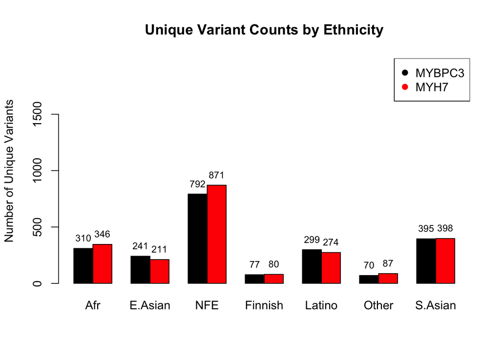

This probably follows relative sample sizes.

### Calculating nucleotide diversity:

#### Multiply all pairs of sequence probabilities, multiply by 2/nts. Sum these up.

Assumptions: variant occurances are independent, only 1 variant can appear per chromosome, no overlaps allowed.

```r
ntd_one_per <- function(freq, nts) {
  2*sum(apply(combn(freq,2),2,prod))*2/nts
}
```

### Nucleotide diversity output

```
##                    Afr      E.Asian         NFE      Finnish       Latino
## ntd.mybpc3 0.001305720 0.0016149354 0.001240712 0.0016271461 0.0014428525
## ntd.myh7   0.003070767 0.0001151375 0.000597285 0.0003353871 0.0002357187
##                   Other      S.Asian
## ntd.mybpc3 0.0010947097 0.0014811054
## ntd.myh7   0.0005151084 0.0004355658
```

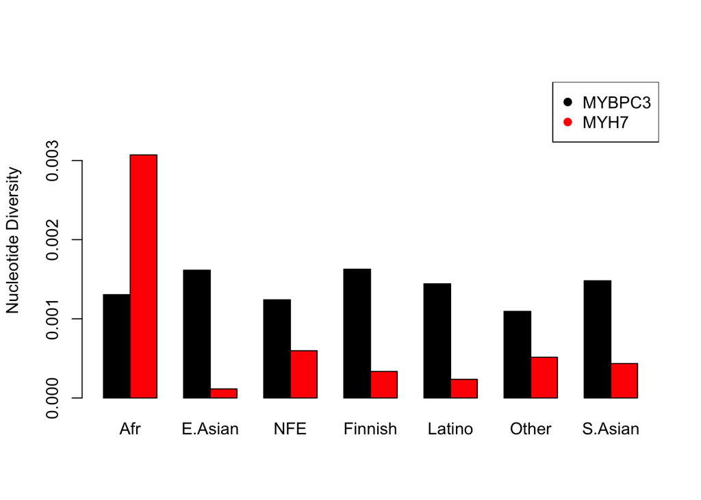

### Calculation takes 1-2 seconds

```
##    user  system elapsed
##   1.709   0.036   1.767
```

### Variants/MYBPC3_gene = total_counts/mean_allele_number

```r
counts_per_chr <- sum(input.mybpc3$Allele_Count)/mean(input.mybpc3$Allele_Number)
counts_per_chr
```

```
## [1] 4.440038
```

It seems like we would want to allow for 4-5 variants per gene. This sounds really hard.

### Combinatorial explosion with multiple variants per gene:

Let n be the number of possible variants and m be the max number of variants/gene allowed.

Possible sequences ($P$) = 100 choose m.  
Possible sequence *pairs* = ${P \choose 2}$, or approximately $P^2/2$ for large $P$.

m = 1 gives us 4950 possibilities.  
m = 4 gives us 7.688000810^{12} possibilities.

Back of the envelope calculations: 1.4 billion times more operations = 50 Tb of storage (if vectorized) and 50 years.

### Addressing overlap: approximate $\pi_{ij}$ using its expected value:

On the whole, you’d expect that taking into account overlap would improve estimates of 2 values:  
1. Slightly increase $\pi$ because now you’re including cases that you weren’t including before (on the order of 0.5% - 5% ). This was estimated by choose(n, 3)/choose(n, 4) for n = 80 and 800.  
2. Slightly decrease your $\hat{\pi_{ij}}$ because you’re including cases that have fewer differences (on the order of 0.1% to 1.3%). This was estimated by pi.est(n,1, nts)/(2/nts) for n = 80 and 800.

$\hat{\pi_{ij}} = weighted.average( \pi_{overlap = 0}, \pi_{overlap = 1}, ... \pi_{overlap = all})$ $\hat{\pi_{ij}} = \frac{ \sum_{i=0}^m \left( weights*\pi_{overlap=i} \right) } {\sum_{i=0}^m (weights)}$  
where *weights* measure how many possible combinations can occur with m overlaps:  
$weights = {n \choose 2m-i} {2m-i \choose i}$ and *$\pi_{overlap = i}$* is given by the fraction: $\pi_{overlap = i} = \frac{2m-i}{nts}$

$2m-i$ is the number of different variants,

$i$ is the number of overlaps,

${n \choose 2m-i}$ is the number of ways that you can choose the nonoverlapping variants,

${2m-i \choose i}$ is the number of ways the two sequence variants can overlap,

$\frac{2m-i}{nts}$ is the proportion of mutually different sites in each type of overlap.

```r
pi.avg <- function(nts, m) {
  sapply(0:m, function(i) (2*m-i)/nts)
}
pi.weights <- function(n, m) {
  sapply(0:m, function(i)
    choose(n, 2*m-i)*
    choose(2*m-i, i)
  )
}
#from n, pick m, with m possible overlaps
pi.est <- function (n, m, nts) {
  sum(pi.avg(nts,m)*pi.weights(n,m))/sum(pi.weights(n,m))
}
```

### Calculating nucleotide diversity - WITH overlap

This sums up This means that the probability of getting any sequence pair is $n \choose 2m$, where n is the number of variant loci, and m is the number of variants per gene. Cases of overlap are hopefully accounted for by $\hat{\pi}$

```r
ntd_m_per <- function(freq, nts, m) {
  2*pi.est(length(freq),m,nts)* #pi is now a constant
    sum(apply(combn(freq,2*m),2,prod))
}
ntd.mybpc3 <- sapply(data.mybpc3, function(x) ntd_m_per(x$Freq, nts.mybpc3, 1))
ntd.myh7 <- sapply(data.myh7, function(x) ntd_m_per(x$Freq, nts.myh7, 1))
ntd.m.2 <- rbind(ntd.mybpc3, ntd.myh7)
ntd.m.2
```

```
##                    Afr      E.Asian         NFE      Finnish       Latino
## ntd.mybpc3 0.001301521 0.0016082621 0.001239148 0.0016062853 0.0014380430
## ntd.myh7   0.003061918 0.0001145944 0.000596600 0.0003312465 0.0002348615
##                   Other      S.Asian
## ntd.mybpc3 0.0010792913 0.0014773653
## ntd.myh7   0.0005092549 0.0004344741
```

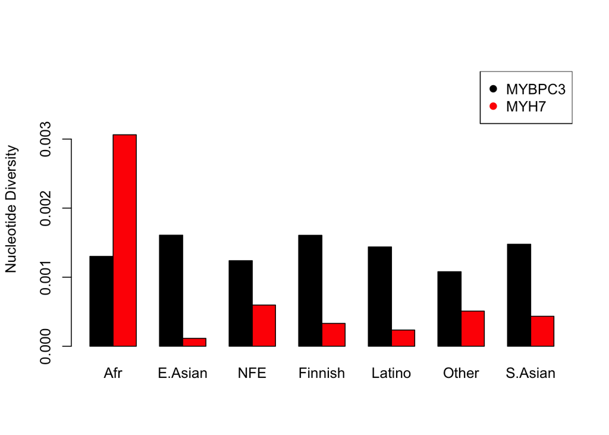

```r
bp <- barplot(ntd.m.2, ylim = c(0,max(ntd.m.2)*1.3),
              ylab = "Nucleotide Diversity", col = c("Black","Red"), beside = T)
legend("topright",c("MYBPC3","MYH7"), pch = 19, col = c("Black","Red"))
```

```r
method_cor <- sapply(c(1:2), function (x) cor(ntd.1[x,], ntd.m.2[x,]))
names(method_cor) <- c("Cor_MYBPC3", "Cor_MYH7")
method_cor
```

```
## Cor_MYBPC3   Cor_MYH7
##  0.9993533  0.9999982
```

```r
method_diff <- sapply(c(1:2), function (x) mean(ntd.m.2[x,]-ntd.1[x,]))
names(method_diff) <- c("Pct_Diff_MYBPC3", "Pct_Diff_MYH7")
method_diff/mean(ntd.1)*100
```

```
## Pct_Diff_MYBPC3   Pct_Diff_MYH7
##      -0.7578708      -0.2914267
```

This still does not overcome combinatorial complexity:  
1. For m = 2 and 77 variants (Fin), we need to sum up more than choose(77 , 4) values = 1.5 million.  
2. For m = 2 and 340 variants (Afr), we need to sum up more than choose(340, 4) values = 500 million.  
3. For m = 2 and 850 variants (NFE), we need to sum up more than choose(850, 4) values = 20,000 million.

### Calculating nucleotide diversity - Bootstrap Simulation

```r
simul_cohort <- function(freq, size) {
  t(sapply(1:size, function(x) rbinom(length(freq), 1, prob = freq)))
}
#cohort <- simul_cohort(data.mybpc3[[4]]$Freq,10000)
#paste(c(1,0,0,1,0), collapse = "")
```

```r
ntd_pair <- function(pair, nts) {
  sum(xor(pair[1,], pair[2,]))/nts
}
#ntd_pair(rbind(c(1,0,1),c(0,0,0)),nts.mybpc3)
```

The simulation takes the list of allele frequencies from each ancestry and calculates mean nt diversity across “pairs” number of pairs:

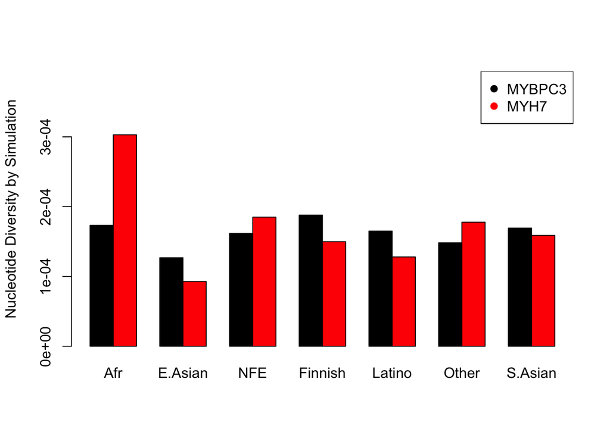

```r
ntd.simul <- function(cohort, pairs, nts) {
  sapply(1:pairs, function(x) ntd_pair(
    cohort[sample(nrow(cohort),2),], nts
    ))
}
raw.output.mybpc3 <- sapply(data.mybpc3, function(x) ntd.simul(simul_cohort(x$Freq, 10000), 10000, nts.mybpc3))
raw.output.myh7 <- sapply(data.myh7, function(x) ntd.simul(simul_cohort(x$Freq, 10000), 10000, nts.myh7))
output <- rbind(colMeans(raw.output.mybpc3), colMeans(raw.output.myh7))
rownames(output) <- c("MYBPC3","MYH7")
bp <- barplot(output, ylim = c(0,max(output)*1.3),
              ylab = "Nucleotide Diversity by Simulation", col = c("Black","Red"), beside = T)
legend("topright",c("MYBPC3","MYH7"), pch = 19, col = c("Black","Red"))
```

```r
output
```

```
##                 Afr      E.Asian          NFE      Finnish       Latino
## MYBPC3 0.0001732907 0.0001268478 0.0001616125 0.0001879135 0.0001650138
## MYH7   0.0003029800 0.0000928098 0.0001850093 0.0001498403 0.0001279693
##               Other      S.Asian
## MYBPC3 0.0001482561 0.0001692734
## MYH7   0.0001777380 0.0001588137
```